# Assignment 7

Manuela Giansante

2023-04-28

```r
library(fpp3)
library(dplyr)
library(urca)
library(forecast)
```

### Exercise 2.Explain what Box-Cox transformation is and when it is applicable. For the following series, find an appropriate Box-Cox transformation and order of differencing in order to obtain stationary data.

A stationary times-series will have no predictable patterns in the long-term, there is no convergence back to an unconditional mean. This means that trend and seasonality can be extracted from a series, therefore predicted, making the series non-stationary. Cycles, because they do not happen within regular intervals they cannot be predicted, a cyclical series is stationary.

Concluding Box-Cox stabilises the variance of the data, not the mean. To stabilise the mean we need to differentiate the time series, so take the differences between consecutive data points.

#### 1. Turkish GDP from global_economy

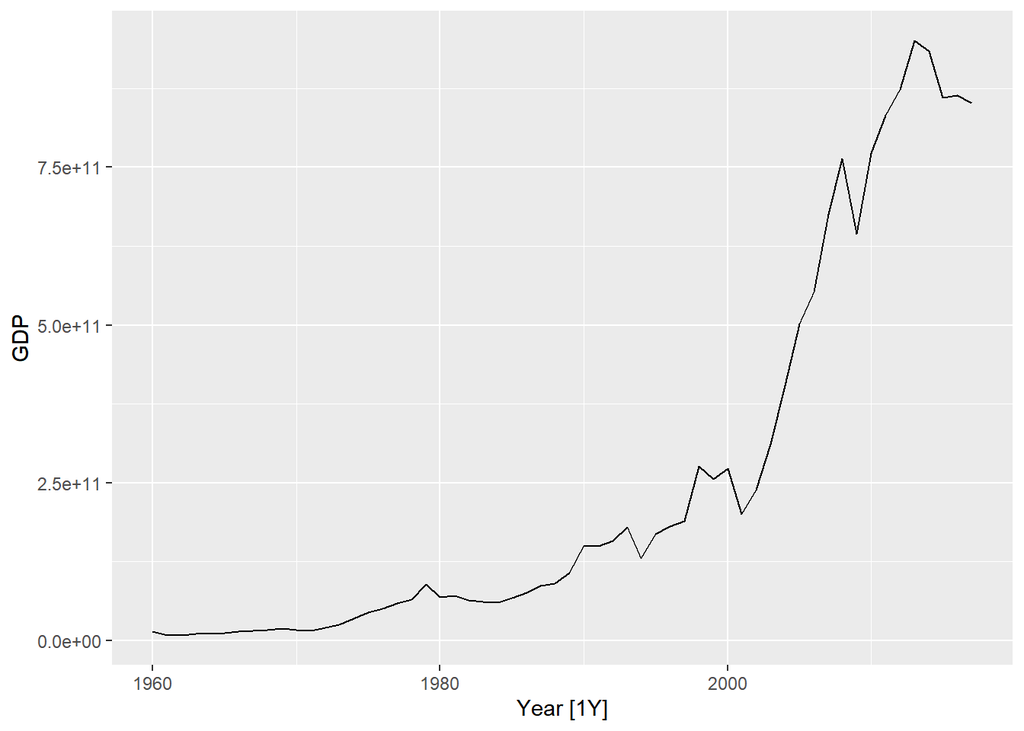

```r
turkey <- global_economy %>%
  filter(Country == "Turkey")

turkeyGDP<-turkey$GDP

turkey %>% autoplot(GDP)
```

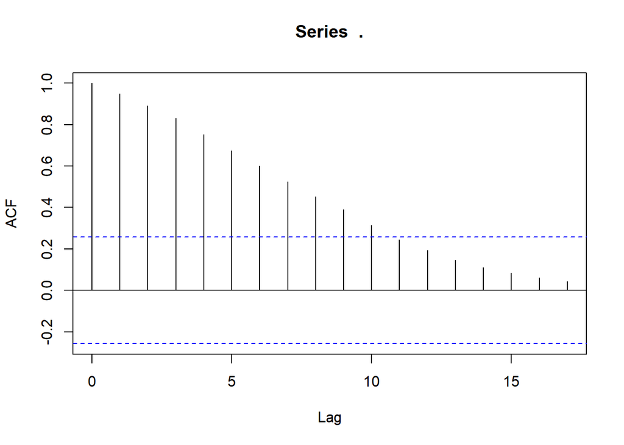

```r
#We check the acf plot
turkey$GDP %>% acf()
```

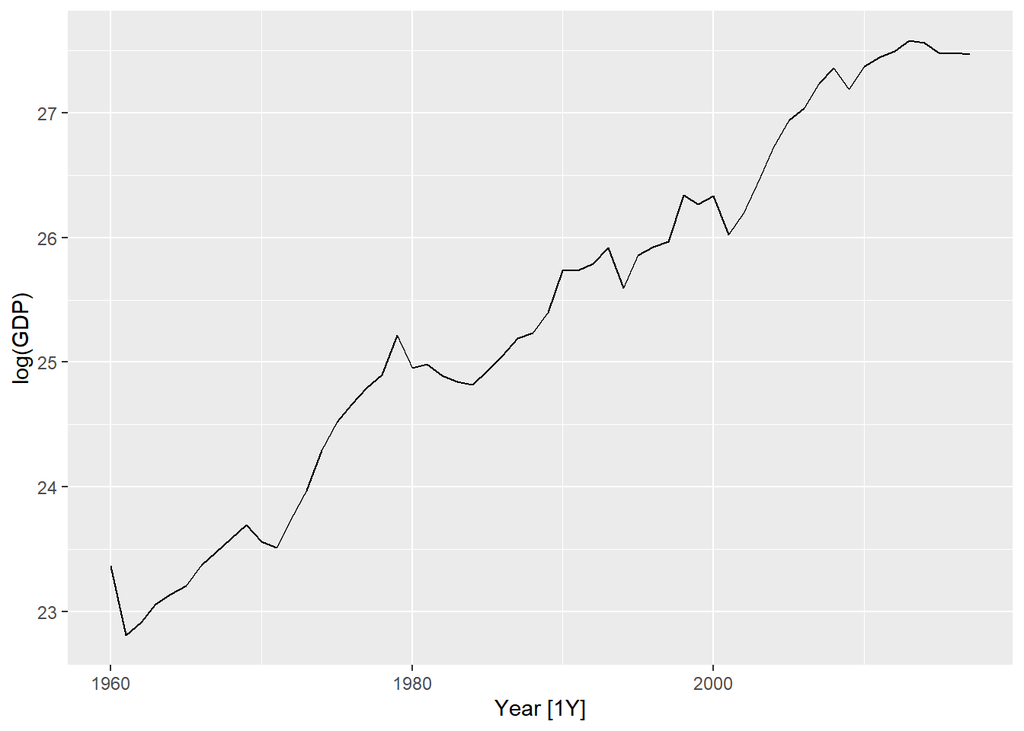

```r
# taking the log of the series
turkey %>% autoplot(log(GDP))
```

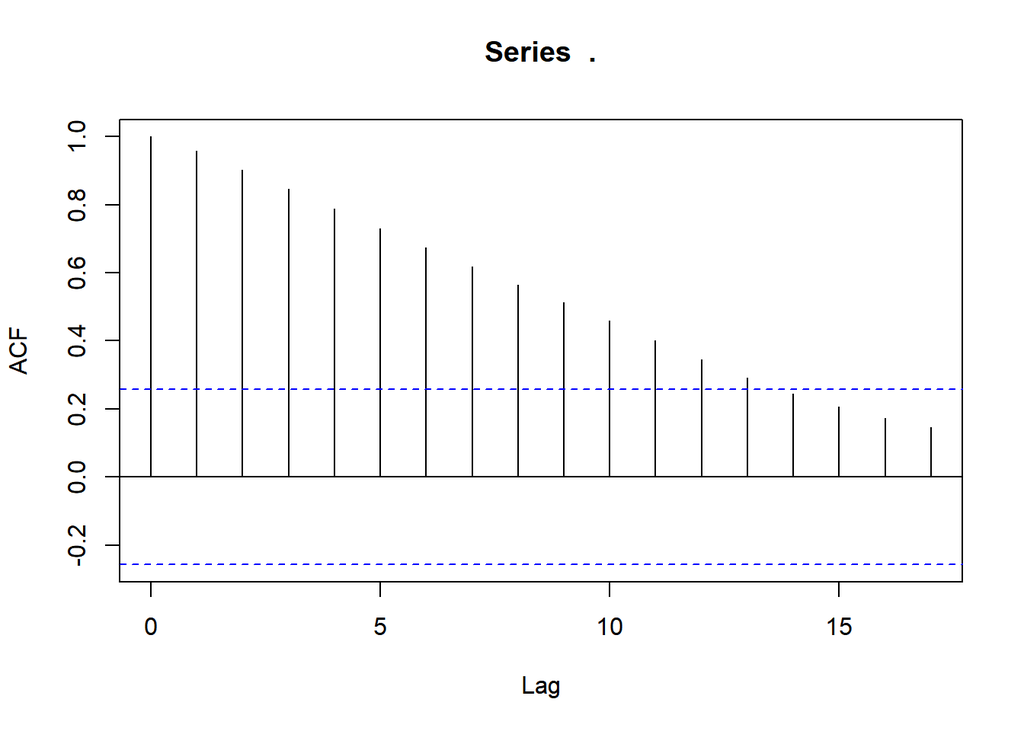

```r
# acf of the logged data
log(turkey$GDP)%>% acf()
```

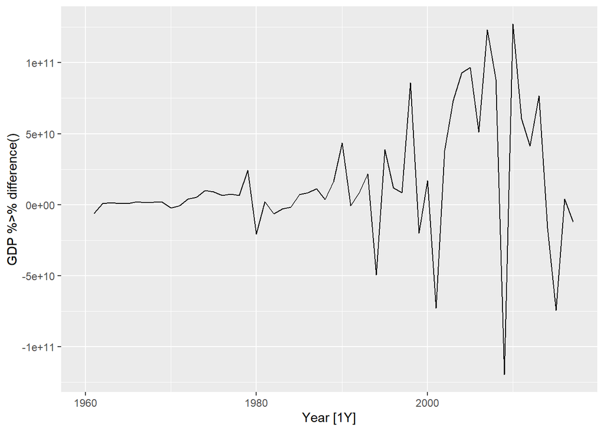

```r
# only differencing
turkey %>% autoplot(GDP %>% difference())
```

The series when plotted out displays growing trend, Turkey’s GDP grows over the years, in fact after 2001 the growth looks exponential. We check the `acf()` on the untransformed series plot to see what kind of differencing is necessary to perform. The series displays no seasonality, after all the data is annual. This is reflected by the autocorrelation plot, the lags decline relatively slowly. The data-point t is correlated with the gdp level of 10 years prior and all records in that interval.

We first try to log transform the data and check the correlogram of it. The transformation seems to have introduced further correlation, the lags now remain significant (outside the 0.95 threshold) up to lag 13. The log might have stabilised the variation, but it worsened the stationarity of the data. We plot the only differenced data, but we can see that the variance is not under control.

Therefore, we apply the logarithm transformation (which could be achieved through Box-Cox with lambda zero) and first order differencing.

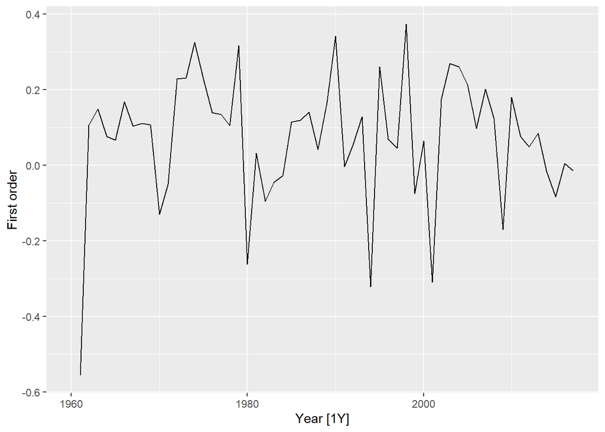

```r
# log and differencing
turkey %>% select(GDP) %>% transmute("First order"= difference(log(GDP))) %>% autoplot()
```

```r
# is the data stationary?
turkey %>% select(GDP) %>% mutate(First_order = difference(log(GDP)))%>% features(First_order, unitroot_kpss)
```

```
## # A tibble: 1 x 2
##   kpss_stat kpss_pvalue
##       <dbl>       <dbl>
## 1    0.0603         0.1
```

```r
#do we need another round of differencing?
turkey %>% select(GDP) %>% mutate(First_order = difference(log(GDP)))%>% features(First_order,unitroot_ndiffs)
```

```
## # A tibble: 1 x 1
##   ndiffs
##    <int>
## 1      0
```

What is plotted out above is no longer the original time series is the annual changes of the logged GDP series. The trend is no longer increasing, and the amplitude of the variation does not change over time. The KPSS reports a p-value of 0.1 so it might be larger than that, meaning we do not reject the null-hypothesis. The data is stationary.

#### 2. Accommodation takings in the state of Tasmania from aus_accommodation.

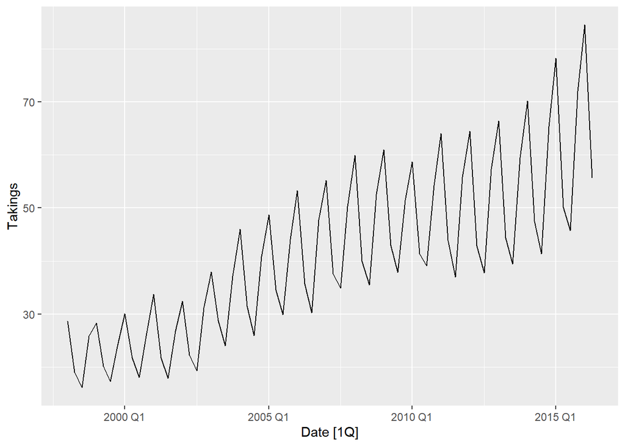

```r
# create the object
Takings_Tas<-aus_accommodation %>% filter(State == "Tasmania")%>% select(Takings)

#plot the series
autoplot(Takings_Tas)
```

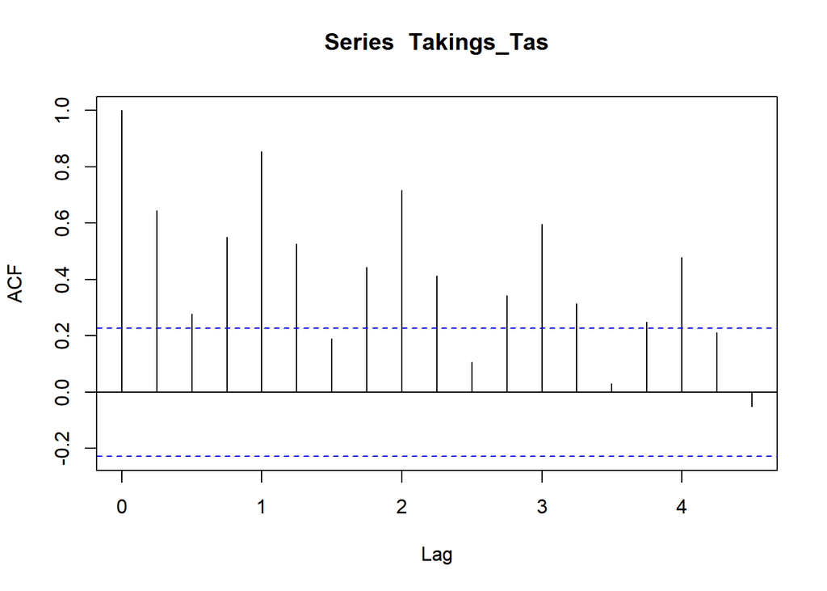

```r
# Autocorrelation
acf(Takings_Tas)
```

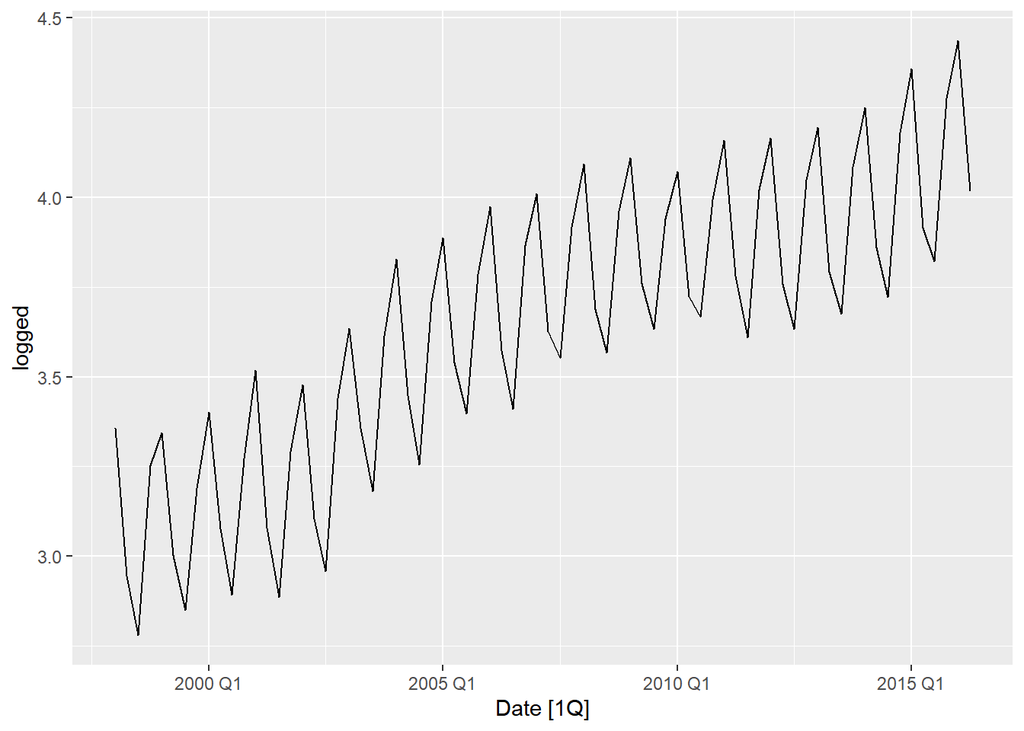

```r
#plot the logged series
Takings_Tas %>% select(Takings) %>% transmute("logged"=log(Takings))%>% autoplot()
```

The data is quarterly, therefore the data might present seasonal patterns. In fact the time series has a very strong seasonal pattern, which increases in amplitude with time. The ACF plot reflects this features of the data, the lags are autocorrelated in a way that reflects the seasonality. It also decays slowly, the data certainly is not stationary.

```r
# How many times should we differentiate?
Takings_Tas %>% select(Takings) %>% mutate(logged =log(Takings))%>% features(logged, unitroot_ndiffs)
```

```
## # A tibble: 1 x 1
##   ndiffs
##    <int>
## 1      1
```

```r
# Seasonal differencing?
Takings_Tas %>% select(Takings) %>% mutate(logged =log(Takings))%>% features(logged, unitroot_nsdiffs)
```

```
## # A tibble: 1 x 1
##   nsdiffs
##     <int>
## 1       1
```

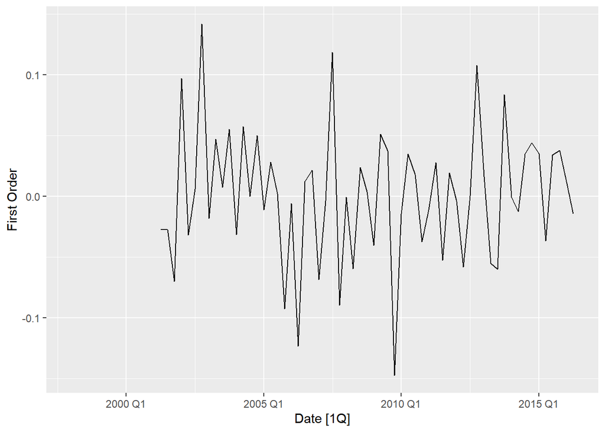

```r
# Differentiate
Takings_Tas %>% select(Takings) %>% transmute("First Order"=difference(difference(log(Takings)),12))%>% autoplot()
```

```r
#KPSS
Takings_Tas %>% select(Takings) %>% mutate(final_model =difference(difference(log(Takings),12)))%>% features(final_model, unitroot_kpss)
```

```
## # A tibble: 1 x 2
##   kpss_stat kpss_pvalue
##       <dbl>       <dbl>
## 1     0.127         0.1
```

We check how many differences seasonal or not we need to take, we transform the series consequently. The KPSS p-value is 0.1 or possibly bigger, the data is stationary.

#### 3. Monthly sales from souvenirs.

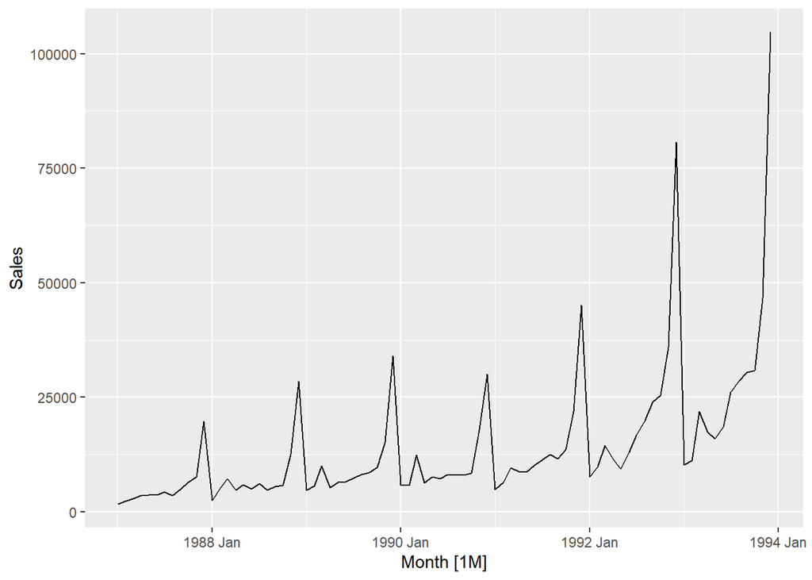

```r
autoplot(souvenirs)
```

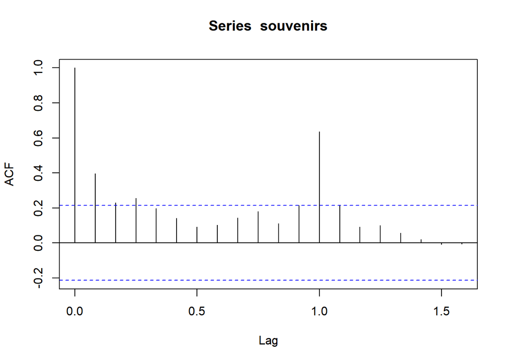

```r
# ACF
acf(souvenirs)
```

The data is monthly, we might have seasonality, plus the trend increase exponentially in the more recent periods.

```r
# How many times should we differentiate?
souvenirs %>% select(Sales) %>% mutate(logged =log(Sales))%>% features(logged, unitroot_ndiffs)
```

```
## # A tibble: 1 x 1
##   ndiffs
##    <int>
## 1      1
```

```r
# Seasonal differencing?
souvenirs %>% select(Sales) %>% mutate(logged =log(Sales))%>% features(logged, unitroot_nsdiffs)
```

```
## # A tibble: 1 x 1
##   nsdiffs
##     <int>
## 1       1
```

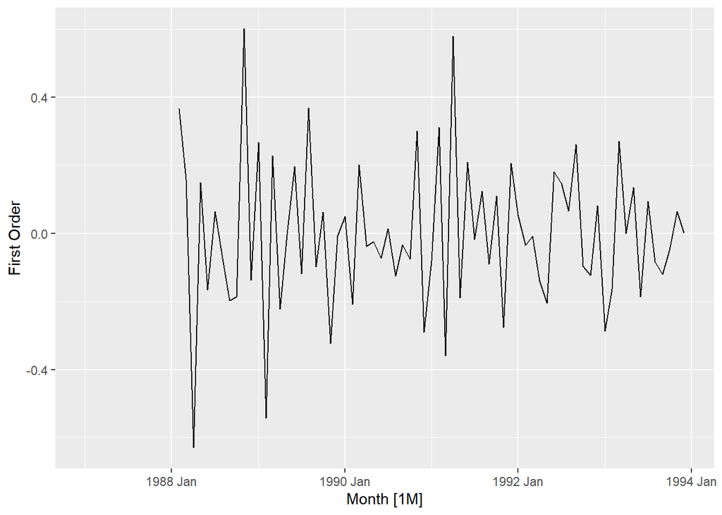

```r
# Differentiate
souvenirs %>% select(Sales) %>% transmute("First Order"=difference(difference(log(Sales)),12))%>% autoplot()
```

```r
#KPSS
souvenirs %>% select(Sales) %>% mutate(final_model =difference(difference(log(Sales),12)))%>% features(final_model, unitroot_kpss)
```

```
## # A tibble: 1 x 2
##   kpss_stat kpss_pvalue
##       <dbl>       <dbl>
## 1    0.0381         0.1
```

### Exercise 4. Consider aus_airpassengers, the total number of passengers (in millions) from Australian air carriers for the period 1970-2011.

```r
head(aus_airpassengers)
```

```
## # A tsibble: 6 x 2 [1Y]
##    Year Passengers
##   <dbl>      <dbl>
## 1  1970       7.32
## 2  1971       7.33
## 3  1972       7.80
## 4  1973       9.38
## 5  1974      10.7
## 6  1975      11.1
```

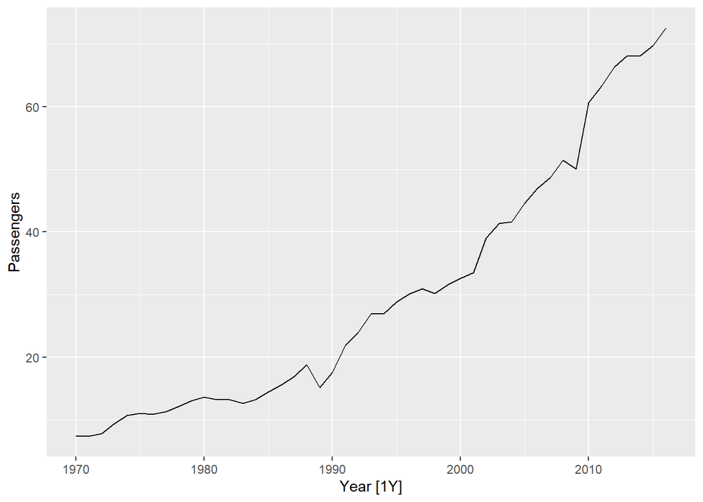

```r
autoplot(aus_airpassengers)
```

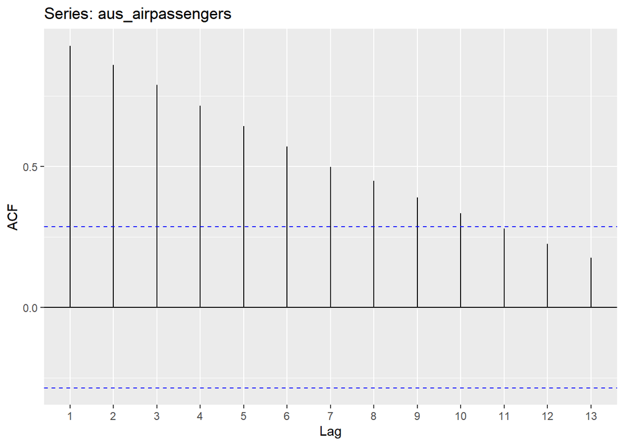

```r
ggAcf(aus_airpassengers)
```

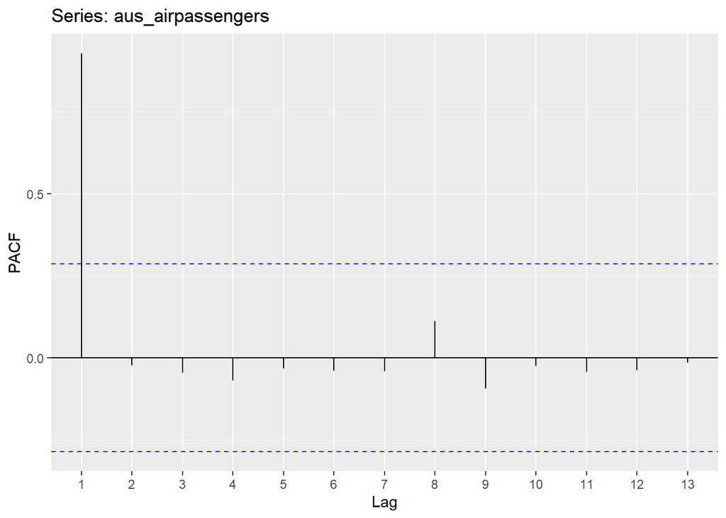

```r
ggPacf(aus_airpassengers)
```

The data is annual, so it cannot be seasonal. The data-series grows in a slightly exponential way, but the variance seems quite constant. Moreover, no cycles seem to be present. The logarithm transformation might not be needed. The ACF graph, decays very slowly, the data is not stationary. The exponential decline of ACF and the single significant lad in PACF, directs us towards a ARIMA(p,d,0).

#### 1. Use ARIMA() to find an appropriate ARIMA model. What model was selected? Check that the residuals look like white noise. Plot forecasts for the next 10 periods.

```r
# Auto.arima()
model<-aus_airpassengers %>% model(ARIMA(Passengers))
report(model)
```

```
## Series: Passengers
## Model: ARIMA(0,2,1)
##
## Coefficients:
##           ma1
##       -0.8963
## s.e.   0.0594
##
## sigma^2 estimated as 4.308:  log likelihood=-97.02
## AIC=198.04   AICc=198.32   BIC=201.65
```

The ARIMA() function selects the ARIMA(0,2,1) model, which indicates that differing is of degree 2 and the moving average part is of order 1. This actually the opposite of what we previewed. The corresponding AIC value is 198.04.

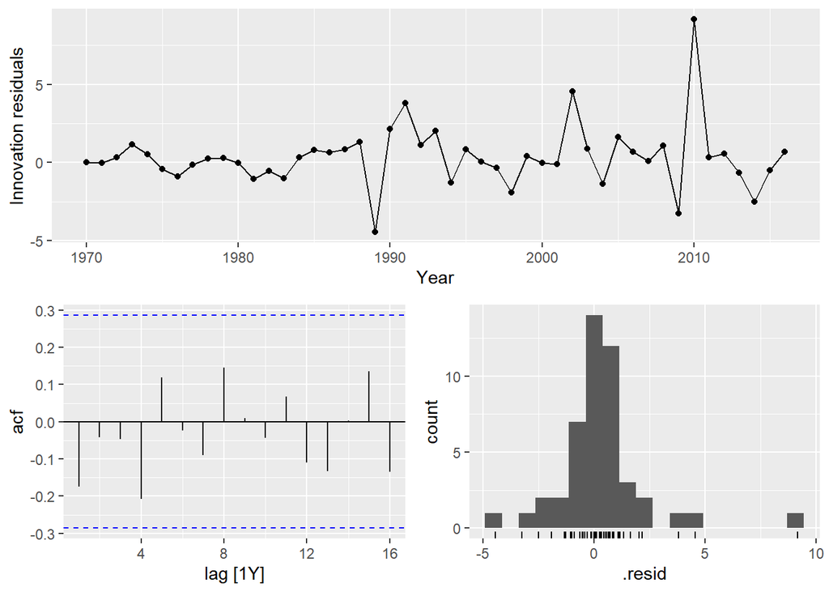

```r
#Check Residuals
aus_airpassengers %>% model(ARIMA(Passengers)) %>% gg_tsresiduals()
```

```r
#Box-Pierce test
augment(model)%>% features(.innov, box_pierce, lag=10)
```

```
## # A tibble: 1 x 3
##   .model            bp_stat bp_pvalue
##   <chr>               <dbl>     <dbl>
## 1 ARIMA(Passengers)    5.81     0.831
```

The residuals are normal, and do not show autocorrelation. The p-value of the Box-Pierce test is large, the residuals cannot be distinguished from white noise. The forecast of ARIMA models stems from the assumption that the model residuals are not serially correlated and they are normally distributed. This means that the forecast we will generate is valid.

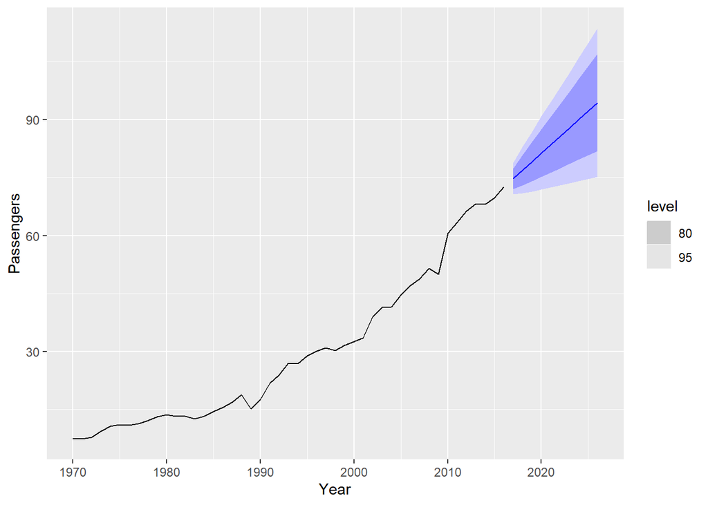

```r
# Plot of the forecast
model %>% fabletools::forecast(h=10)%>% autoplot(aus_airpassengers)
```

d=2 but c=0 the forecast is a straight line.

#### 2. Write this model in terms of the backshift operator.

$(1-B)^2y_t=(1+\Theta_1B)e_t$

#### 3. Plot forecasts from an ARIMA(0,1,0) model with drift and compare these to part 1.

```r
model2<-aus_airpassengers %>% model(ARIMA(Passengers ~ 1 + pdq(0,1,0)))
report(model2)
```

```
## Series: Passengers
## Model: ARIMA(0,1,0) w/ drift
##
## Coefficients:
##       constant
##         1.4191
## s.e.    0.3014
##
## sigma^2 estimated as 4.271:  log likelihood=-98.16
## AIC=200.31   AICc=200.59   BIC=203.97
```

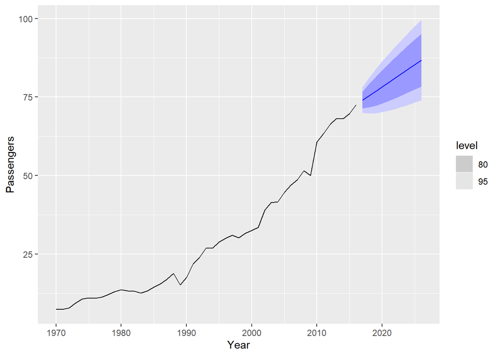

```r
model2 %>% fabletools::forecast(h=10)%>% autoplot(aus_airpassengers)
```

Differencing is of first order in this model. Given that d=1, the PI will continue to grow in the future, but compared to other modelling approaches the PI are usually more narrow because only the variation in the errors is included in the generation of the intervals. The information criteria for the model is higher than the model selected by auto.arima(). The better model in terms of information criteria is still the first model that was generated.

The addition of the constant means adding a drift to the model. We can write $y_t=\delta + y_{t-1}+\epsilon_t$. It helps modelling the trend because on average the fitted model will grow each period by that drift amount. A simple random walk with drift does not have a precise level to which “it returns” in the long run. This means that when a shock happens that brings the level up, the fitted model will not behave so to re-converge to the level pre-shock.

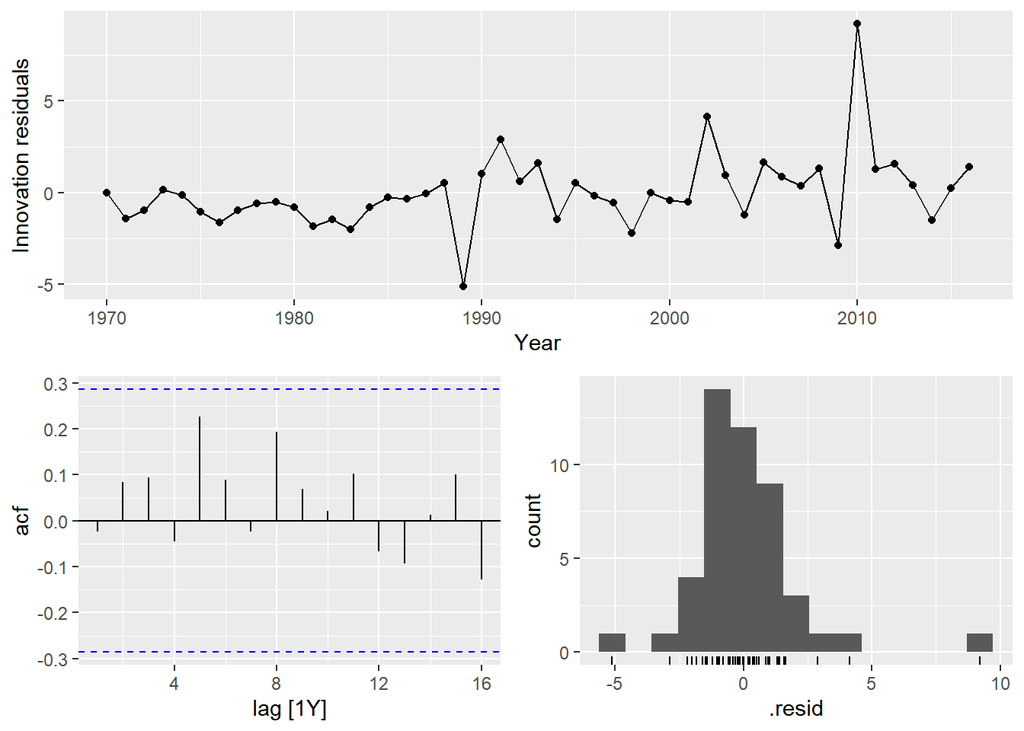

```r
# Check residuals
gg_tsresiduals(model2)
```

#### 4. Plot forecasts from an ARIMA(2,1,2) model with drift and compare these to parts 1 and 3. Remove the constant and see what happens.

```r
model3 <-aus_airpassengers %>% model(ARIMA(Passengers ~ 1 + pdq(2,1,2)))
report(model3)
```

```
## Series: Passengers
## Model: ARIMA(2,1,2) w/ drift
##
## Coefficients:
##           ar1      ar2     ma1     ma2  constant
##       -0.5518  -0.7327  0.5895  1.0000    3.2216
## s.e.   0.1684   0.1224  0.0916  0.1008    0.7224
##
## sigma^2 estimated as 4.031:  log likelihood=-96.23
## AIC=204.46   AICc=206.61   BIC=215.43
```

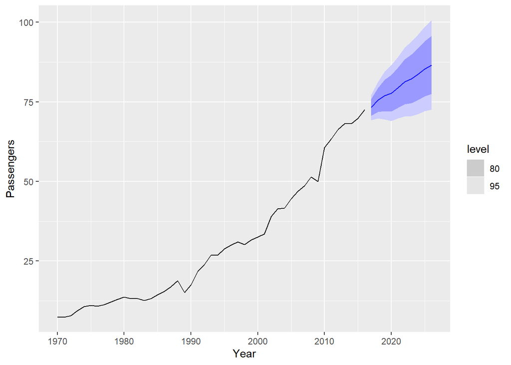

```r
model3 %>% fabletools::forecast(h=10)%>% autoplot(aus_airpassengers)
```

AIC and AICc here are even higher than the two previous cases, after all the complexity ($p+q+k+1$) of this model is higher than in the other two cases. The d value has not changed, we notice instead that the PIs vary in the 10 steps ahead forecast. In this case there might be redundancy within the model, we note ar1=-0.55 and ma1=0.58 and similar but not as close for ar2 and ma2.The model might be over-parametrized.

```r
model3_c <-aus_airpassengers %>% model(ARIMA(Passengers ~ pdq(2,1,2)))
report(model3_c)
```

```
## Series: Passengers
## Model: NULL model
## NULL model
```

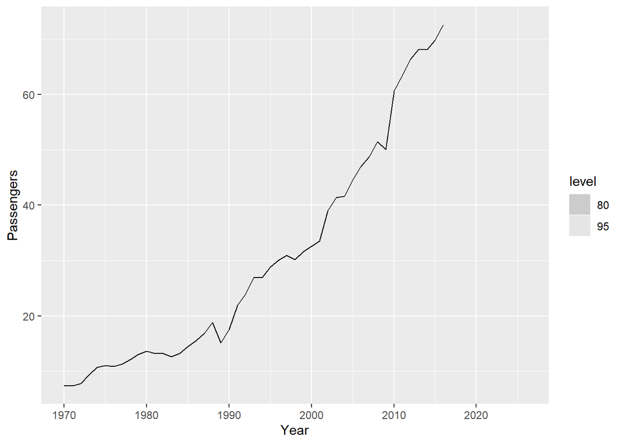

```r
model3_c %>% fabletools::forecast(h=10)%>% autoplot(aus_airpassengers)
```

The model is null, probably because the addition of the constant term allowed for the increasing trend to be modelled. The autoregressive model and the moving average portion of the model fails to model the trend. Adding a drift in a first order differenced (d=1) series, indicates that there is core change in the changes we estimate over time. (https://stats.stackexchange.com/questions/163394/constant-in-arima-model-whether-to-include-or-exclude)

#### 5. Plot forecasts from an ARIMA(0,2,1) model with a constant. What happens?

```r
model4 <-aus_airpassengers %>% model(ARIMA(Passengers ~1 + pdq(0,2,1)))
report(model4)
```

```
## Series: Passengers
## Model: ARIMA(0,2,1) w/ poly
##
## Coefficients:
##           ma1  constant
##       -1.0000    0.0571
## s.e.   0.0585    0.0213
##
## sigma^2 estimated as 3.855:  log likelihood=-95.1
## AIC=196.21   AICc=196.79   BIC=201.63
```

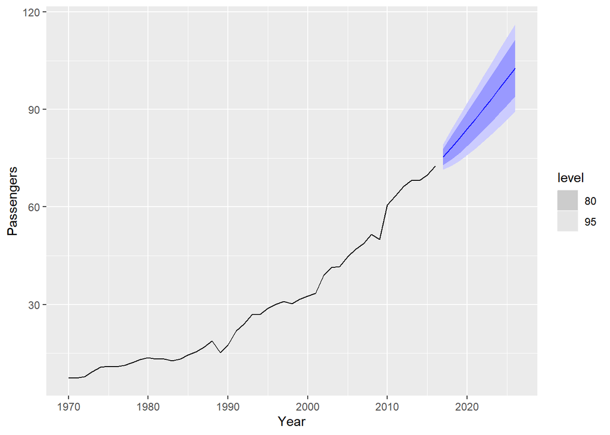

```r
model4 %>% fabletools::forecast(h=10)%>% autoplot(aus_airpassengers)
```

d=2 is now larger, than the model above, the intervals of the prediction in this case grow in amplitude more quickly than d=0. This model compared to the same model generated in point 1 of the exercise but without drift,has a point forecast that is steeper in slope, with smaller confidence intervals. Usually a constant is included unless d=2, which here is the case, and also the reason why ARIMA(0,2,1) did not return a null model.